# Time Series 03: Cleaning & Subsetting Time Series Data in R - NoData Values & Subset by Date

This tutorial explores how to deal with `NoData` values encountered in a time series dataset, in R. It also covers how to subset large files by date and export the results to a `.csv` (text) file.

## Learning Objectives

After completing this tutorial, you will be able to:

- Subset data by date.
- Search for NA or missing data values.
- Describe different possibilities on how to deal with missing data.

## Things You’ll Need To Complete This Tutorial

You will need the most current version of R and, preferably, RStudio loaded on your computer to complete this tutorial.

### Install R Packages

- **lubridate:** `install.packages("lubridate")`
- **ggplot2:** `install.packages("ggplot2")`

[More on Packages in R](https://www.neonscience.org/packages-in-r) – Adapted from Software Carpentry.

### [NEON Teaching Data Subset: Meteorological Data for Harvard Forest](https://ndownloader.figshare.com/files/3701572)

The data used in this lesson were collected at the [National Ecological Observatory Network’s](https://www.neonscience.org/) [Harvard Forest field site](https://www.neonscience.org/field-sites/field-sites-map/HARV). These data are proxy data for what will be available for 30 years on the [NEON data portal](http://data.neonscience.org/) for the Harvard Forest and other field sites located across the United States.

[Download Dataset](https://ndownloader.figshare.com/files/3701572)

**Set Working Directory:** This lesson assumes that you have set your working directory to the location of the downloaded and unzipped data subsets.

[An overview of setting the working directory in R can be found here.](https://www.neonscience.org/set-working-directory-r)

**R Script & Challenge Code:** NEON data lessons often contain challenges that reinforce learned skills. If available, the code for challenge solutions is found in the downloadable R script of the entire lesson, available in the footer of each lesson page.

## Cleaning Time Series Data

It is common to encounter, large files containing more data than we need for our analysis. It is also common to encounter `NoData` values that we need to account for when analyzing our data.

In this tutorial, we’ll learn how to both manage `NoData` values and also subset and export a portion of an R object as a new `.csv` file.

In this tutorial, we will work with atmospheric data, containing air temperature, precipitation, and photosynthetically active radiation (PAR) data - metrics that are key drivers of phenology. Our study area is the [NEON Harvard Forest Field Site.](https://www.neonscience.org/field-sites/field-sites-map/HARV)

## Import Timeseries Data

We will use the `lubridate` and `ggplot2` packages. Let’s load those first.

If you have not already done so, import the `hf001-10-15min-m.csv` file, which contains atmospheric data for Harvard Forest. Convert the `datetime` column to a `POSIXct` class as covered in the tutorial: [*Dealing With Dates & Times in R - as.Date, POSIXct, POSIXlt*](https://www.neonscience.org/dc-brief-tabular-time-series-qplot-r).

```r
# Load packages required for entire script
library(lubridate)  # work with dates
```

```r
library(ggplot2)  # plotting

# set working directory to ensure R can find the file we wish to import
wd <- "~/Documents/"

# Load csv file containing 15 minute averaged atmospheric data
# for the NEON Harvard Forest Field Site

# Factors=FALSE so data are imported as numbers and characters
harMet_15Min <- read.csv(
  file=paste0(wd,"NEON-DS-Met-Time-Series/HARV/FisherTower-Met/hf001-10-15min-m.csv"),
  stringsAsFactors = FALSE)

# convert to POSIX date time class - US Eastern Time Zone
harMet_15Min$datetime <- as.POSIXct(harMet_15Min$datetime,
                                format = "%Y-%m-%dT%H:%M",
                                tz = "America/New_York")
```

## Subset by Date

Our `.csv` file contains nearly a decade’s worth of data which makes for a large file. The time period we are interested in for our study is:

- Start Time: 1 January 2009
- End Time: 31 Dec 2011

Let’s subset the data to only contain these three years. We can use the `subset()` function, with the syntax: `NewObject <- subset ( ObjectToBeSubset, CriteriaForSubsetting )`.

We will set our criteria to be any `datetime` that:

1. Is greater than or equal to 1 Jan 2009 at 0:00 **AND**
2. Is less than or equal to 31 Dec 2011 at 23:59.

We also need to specify the `timezone` so R can handle daylight savings and leap year.

```r
# subset data - 2009-2011
harMet15.09.11 <- subset(harMet_15Min,
                         datetime >= as.POSIXct('2009-01-01 00:00',
                                                tz = "America/New_York") &
                         datetime <= as.POSIXct('2011-12-31 23:59',
                                               tz = "America/New_York"))

# View first and last records in the object
head(harMet15.09.11[1])
```

```
##                   datetime
## 140255 2009-01-01 00:00:00
## 140256 2009-01-01 00:15:00
## 140257 2009-01-01 00:30:00
## 140258 2009-01-01 00:45:00
## 140259 2009-01-01 01:00:00
## 140260 2009-01-01 01:15:00
```

```r
tail(harMet15.09.11[1])
```

```
##                   datetime
## 245369 2011-12-31 22:30:00
## 245370 2011-12-31 22:45:00
## 245371 2011-12-31 23:00:00
## 245372 2011-12-31 23:15:00
## 245373 2011-12-31 23:30:00
## 245374 2011-12-31 23:45:00
```

It worked! The first entry is 1 January 2009 at 00:00 and the last entry is 31 December 2011 at 23:45.

### Export data.frame to .CSV

We can export this subset in `.csv` format to use in other analyses or to share with colleagues using `write.csv`.

**Data Tip:** Remember, to give your output files concise, yet descriptive names so you can identify what it contains in the future. By default, the `.csv` file will be written to your working directory.

```r
# write harMet15 subset data to .csv
write.csv(harMet15.09.11,
          file=paste0(wd,"Met_HARV_15min_2009_2011.csv"))
```

### Challenge: Subset & Plot Data

1. Create a plot of precipitation for the month of July 2010 in Harvard Forest. Be sure to label x and y axes. Also be sure to give your plot a title.
2. Create a plot of dew point (`dewp`) for the year 2011 at Harvard Forest.

**Bonus challenge:** Complete this challenge using the available daily data instead of the 15-minute data. What will need to change in your subsetting code?

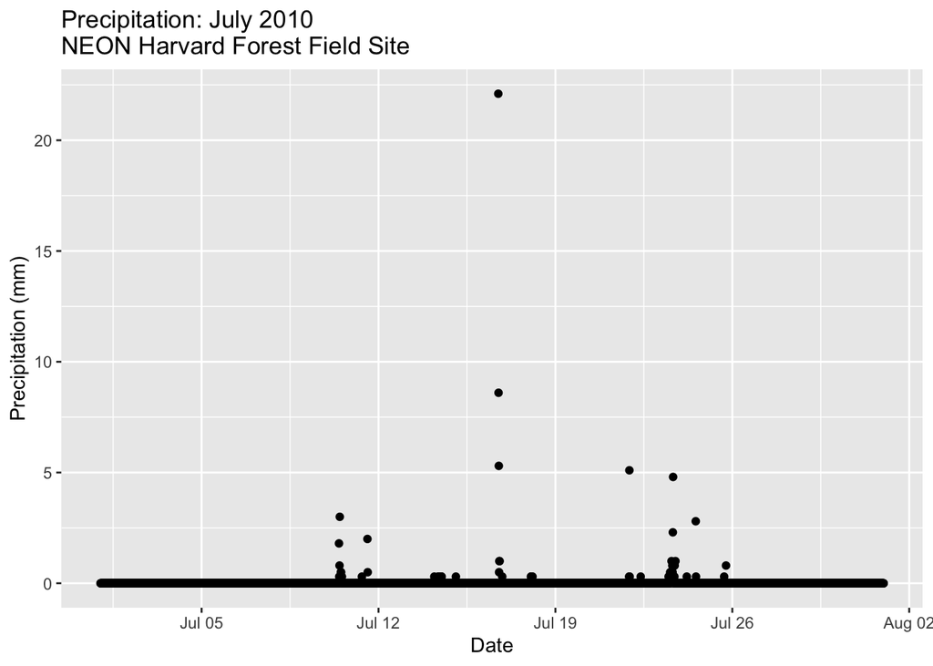

Daily Rainfall at Harvard Forest for the month of July, 2010

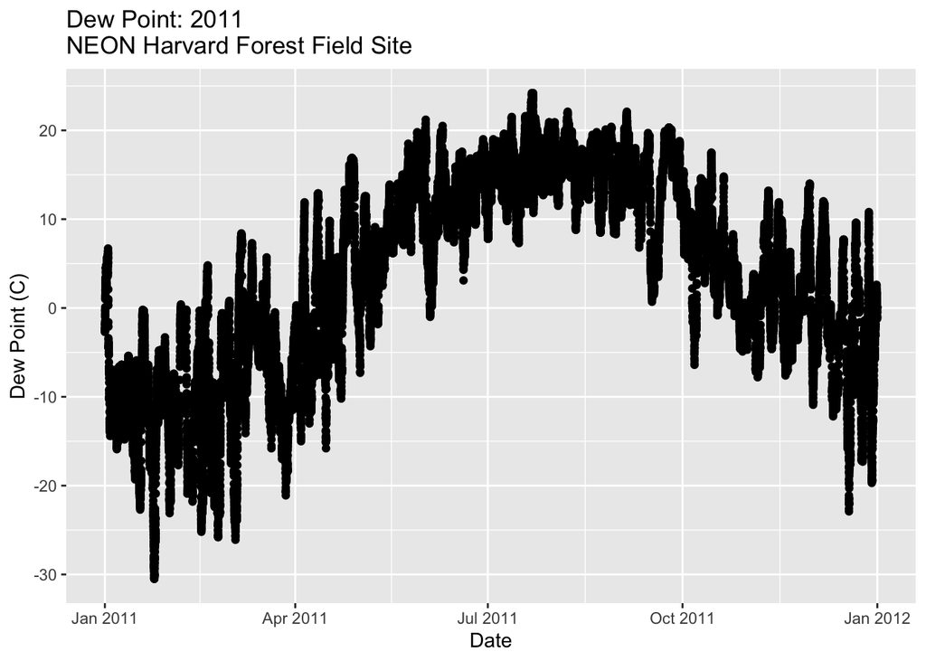

## Managing Missing Data: NoData values

### Find NoData Values

If we are lucky when working with external data, the `NoData` value is clearly specified in the metadata. No data values can be stored differently:

- **NA / NaN:** Sometimes this value is `NA` or `NaN` (not a number).
- **A Designated Numeric Value (e.g. -9999):** Character strings such as `NA` can not always be stored along side of numeric values in some file formats. Sometimes you’ll encounter numeric placeholders for `noData` values such as `-9999` (a value often used in the GIS / Remote Sensing and Micrometerology domains.
- **Blank Values:** sometimes `noData` values are left blank. Blanks are particularly problematic because we can’t be certain if a data value is purposefully missing (not measured that day or a bad measurement) or if someone unintentionally deleted it.

Because the actual value used to designate missing data can vary depending upon what data we are working with, it is important to always check the metadata for the files associated `NoData` value. If the value is `NA`, we are in luck, R will recognize and flag this value as `NoData`. If the value is numeric (e.g., `-9999`), then we might need to assign this value to `NA`.

**Data Tip:** `NA` values will be ignored when performing calculations in R. However a `NoData` value of `-9999` will be recognized as an integer and processed accordingly. If you encounter a numeric `NoData` value be sure to assign it to `NA` in R: `objectName[objectName==-9999] <- NA`

In the [*Why Metadata Are Important: How to Work with Metadata in Text & EML Format* tutorial](https://www.neonscience.org/dc-metadata-importance-eml-r), we viewed the metadata for these data and discovered that missing values are designated using `NA` - a common `NoData` value placeholder.

> **Excerpt from the metadata:** `airt: average air temperature. Average of daily averages. (unit: celsius / missing value: NA)`

### Check For NoData Values

We can quickly check for `NoData` values in our data using the`is.na()` function. By asking for the `sum()` of `is.na()` we can see how many NA/ missing values we have.

```r
# Check for NA values
sum(is.na(harMet15.09.11$datetime))
```

```
## [1] 0
```

```r
sum(is.na(harMet15.09.11$airt))
```

```
## [1] 2
```

```r
# view rows where the air temperature is NA
harMet15.09.11[is.na(harMet15.09.11$airt),]
```

```
##                   datetime  jd airt f.airt rh f.rh dewp f.dewp prec f.prec slrr
## 158360 2009-07-08 14:15:00 189   NA      M NA    M   NA      M    0         290
## 203173 2010-10-18 09:30:00 291   NA      M NA    M   NA      M    0          NA
##        f.slrr parr f.parr netr f.netr bar f.bar wspd f.wspd wres f.wres wdir
## 158360         485         139         NA     M  2.1         1.8          86
## 203173      M   NA      M   NA      M  NA     M   NA      M   NA      M   NA
##        f.wdir wdev f.wdev gspd f.gspd s10t f.s10t
## 158360          29         5.2        20.7
## 203173      M   NA      M   NA      M 10.9
```

The results above tell us there are `NoData` values in the `airt` column. However, there are `NoData` values in other variables.

### Challenge: NoData Values

How many `NoData` values are in the precipitation (`prec`) and PAR (`parr`) columns of our data?

### Deal with NoData Values

When we encounter `NoData` values (blank, NaN, -9999, etc.) in our data we need to decide how to deal with them. By default R treats `NoData` values designated with a `NA` as a missing value rather than a zero. This is good, as a value of zero (no rain today) is not the same as missing data (e.g. we didn’t measure the amount of rainfall today).

How we deal with `NoData` values will depend on:

- the data type we are working with
- the analysis we are conducting
- the significance of the gap or missing value

Many functions in R contains a `na.rm=` option which will allow you to tell R to ignore `NA` values in your data when performing calculations.

### To Gap Fill? Or Not?

Sometimes we might need to “gap fill” our data. This means we will interpolate or estimate missing values often using statistical methods. Gap filling can be complex and is beyond the scope of this tutorial. The take away from this is simply that it is important to acknowledge missing values in your data and to carefully consider how you wish to account for them during analysis.

Other resources:

1. R code for dealing with missing data: [Quick-R: Missing Data](http://www.statmethods.net/input/missingdata.html)

### Managing NoData Values in Our Data

For this tutorial, we are exploring the patterns of precipitation, and temperature as they relate to green-up and brown-down of vegetation at Harvard Forest. To view overall trends during these early exploration stages, it is okay for us to leave out the `NoData` values in our plots.

**Data Tip:** If we wanted to perform more advanced statistical analysis, we might consider gap-filling as our next step. Many data products, from towers such as FluxNet include a higher level, gap-filled product that we can download. [More on Gap Filling](http://www.archive.arm.gov/Carbon/gapfilling/gapfilling.html)

### NoData Values Can Impact Calculations

It is important to consider `NoData` values when performing calculations on our data. For example, R will not properly calculate certain functions if there are `NA` values in the data, unless we explicitly tell it to ignore them.

```r
# calculate mean of air temperature
mean(harMet15.09.11$airt)
```

```
## [1] NA
```

```r
# are there NA values in our data?
sum(is.na(harMet15.09.11$airt))
```

```
## [1] 2
```

R will not return a value for the mean as there `NA` values in the air temperature column. Because there are only 2 missing values (out of 105,108) for air temperature, we aren’t that worried about a skewed 3 year mean. We can tell R to ignore noData values in the mean calculations using `na.rm=` (NA.remove).

```r
# calculate mean of air temperature, ignore NA values
mean(harMet15.09.11$airt,
     na.rm=TRUE)
```

```
## [1] 8.467904
```

We now see that the 3-year average air temperature is 8.5°C.

### Challenge: Import, Understand Metadata, and Clean a Data Set

We have been using the 15-minute data from the Harvard Forest. However, overall we are interested in larger scale patterns of greening-up and browning-down.  
Thus a daily summary is sufficient for us to see overall trends.

1. Import the Daily Meteorological data from the Harvard Forest (if you haven’t already done so in the [*Intro to Time Series Data in R*](https://www.neonscience.org/dc-brief-tabular-time-series-qplot-r) tutorial.)
2. Check the metadata to see what the column names are for the variable of interest (precipitation, air temperature, PAR, day and time ).
3. If needed, convert the data class of different columns.
4. Check for missing data and decide what to do with any that exist.
5. Subset out the data for the duration of our study: 2009-2011. Name the object “harMetDaily.09.11”.
6. Export the subset to a `.csv` file.
7. Create a plot of Daily Air Temperature for 2009-2011. Be sure to label, x- and y-axes. Also give the plot a title!

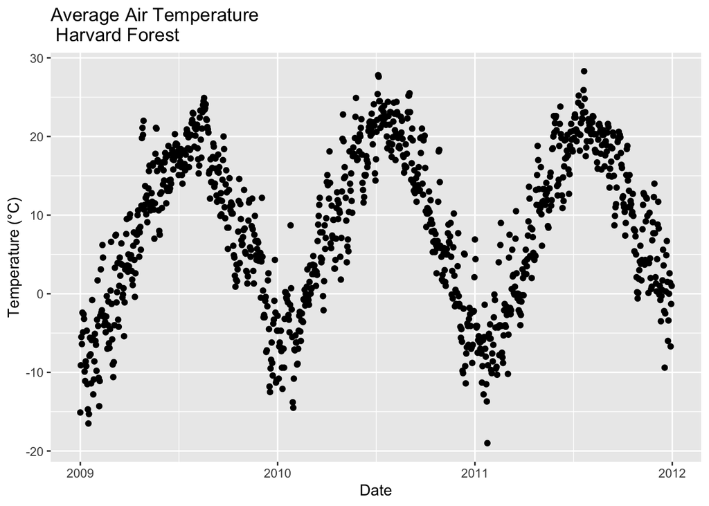

Relationship between Date and Daily Average Temperature at Harvard Forest between 2009 and 2012